# Завдання 1.1

В чому різниця запитів? Чим будуть відрізнятись отримані результати?

```
SELECT *
FROM table1
LEFT JOIN table2 USING (name)
WHERE table2.name = 'John'

SELECT *
FROM table1
JOIN table2 USING (name)
WHERE table2.name = 'John'
```

### Відповідь:

В першому випадку для обєднання таблиць використали LEFT JOIN який теоретично виводить всі результати з table1 навіть якщо немає відповідника у table2, але при цьому використали фільтр для імені з table2 "WHERE table2.name = 'John'" , що відкидає з неї нульові результати. В другому випадку використано JOIN, що виводить всі записи, де name співпадає в обох таблицях також з фільтром по імені з table2 "WHERE table2.name = 'John'" Отже результат обох таблиць буде однаковим тому що фільтр table2.name = 'John' у WHERE блокує будь-які рядки без відповідника в table2

# Завдання 1.2

### Аналіз Total Spend (ТС) по користувачах

Витягнути всіх користувачів, ТС яких вище за середній ТС у їхньому регіоні

### SQL-запит (BigQuery )

```
WITH avg_by_region AS (
  SELECT
    id_region,
    AVG(amount) AS avg_amount
  FROM `task.total_spend`
  GROUP BY id_region
)

SELECT
  t.id_user,
  t.id_region,
  t.amount
FROM `task.total_spend` t
JOIN avg_by_region a
  ON t.id_region = a.id_region
WHERE t.amount > a.avg_amount
ORDER BY t.id_region
```

### SQL-результат:

[Результат](https://docs.google.com/spreadsheets/d/1Cpn2zWST98SMgsJc2zCgDK3LLRK4n0KwsvV_yux_I-o/edit?usp=sharing)

### Візуалізація результату (Looker Studio)

[Looker Studio](https://lookerstudio.google.com/reporting/81c51dab-272c-4b6a-beaf-edb9b03000e9)

[figure not shown]

# Завдання 2

Проаналізувати, як можна покращити рівень обслуговування клієнтів.

#### Вхідні дані:

- Кожен продукт має свою команду підтримки.
- Кожне завдання старанний агент служби підтримки може виконувати до 5 хвилин з момента взяття в роботу.
- З боку менеджменту є очікування, що в рамках кожного дня середній час від виникнення нового запиту користувача до відповіді має бути 15 хвилин. Також погано, якщо користувачі сервісу чекають на відповідь довше 45 хвилин.

#### Опис даних:

- Таблиця events - дані про кожний запит до модерації. Містять в собі інформацію про сам запит та модератора, який його виконував.
- id_request - унікальний ідентифікатор запиту;
- moderator - унікальний ідентифікатор агента підтримки;
- team - параметр команди (retail / wholesale);
- request_time - час отримання запиту;
- start_time - час початку обробки кейсу;
- finish_time - час кінця обробки кейсу.

# Аналіз ефективності служби підтримки

Цей звіт включає аналітику за завданнями:

- Загальні KPI по роботі служби підтримки
- Аналіз середнього часу відповіді та обробки.
- Середній час відповіді по командах
- Розподіл задач за часом відповіді
- Аналіз FIFO: чи обробляють задачі в черговості
- Динаміка запитів і рішень по днях
- Аналіз середнього часу відповіді по годинах і динаміки кількості запитів.
- Кількість невирішених задач щодня та накопичення невирішених задач
- Активність модераторів

Мета: знайти причини затримок, оцінити дотримання очікувань менеджменту та сформувати рекомендації.

```python
import pandas as pd
import matplotlib.pyplot as plt
import numpy as np
import seaborn as sns
# Завантаження даних
events_df = pd.read_csv("events.csv")
events_df.head(10)
```

|  | moderator | id_request | request_time | start_time | finish_time | team |
| --- | --- | --- | --- | --- | --- | --- |
| 0 | 165 | 159660 | 2020-09-24 7:01:16 | 2020-10-01 16:00:31 | 2020-10-01 16:02:02 | retail |
| 1 | 178 | 160116 | 2020-09-24 22:32:15 | 2020-10-01 13:21:42 | 2020-10-01 13:21:43 | retail |
| 2 | 187 | 160178 | 2020-09-25 2:58:13 | 2020-10-02 11:37:16 | 2020-10-02 11:41:56 | wholesale |
| 3 | 178 | 160306 | 2020-09-25 9:44:12 | 2020-10-02 7:23:09 | 2020-10-02 7:25:33 | retail |
| 4 | 178 | 163042 | 2020-09-30 15:56:08 | 2020-10-02 7:37:33 | 2020-10-02 7:47:57 | retail |
| 5 | 128 | 163426 | 2020-10-01 0:58:24 | 2020-10-01 7:07:31 | 2020-10-01 7:08:22 | wholesale |
| 6 | 128 | 163427 | 2020-10-01 1:02:20 | 2020-10-01 8:03:58 | 2020-10-01 8:06:52 | wholesale |
| 7 | 128 | 163428 | 2020-10-01 1:04:15 | 2020-10-01 7:09:57 | 2020-10-01 7:12:06 | wholesale |
| 8 | 128 | 163429 | 2020-10-01 1:07:15 | 2020-10-01 7:12:06 | 2020-10-01 7:13:15 | wholesale |
| 9 | 128 | 163431 | 2020-10-01 1:14:13 | 2020-10-01 7:16:04 | 2020-10-01 7:17:05 | wholesale |

```python
# Приведення до datetime
events_df['request_time'] = pd.to_datetime(events_df['request_time'])
events_df['start_time'] = pd.to_datetime(events_df['start_time'])
events_df['finish_time'] = pd.to_datetime(events_df['finish_time'])
# Приведення до datetime
events_df.dtypes
```

```
moderator                int64
id_request               int64
request_time    datetime64[ns]
start_time      datetime64[ns]
finish_time     datetime64[ns]
team                    object
dtype: object
```

```python
# Обчислення response_time та handling_time
events_df['response_time'] = ((events_df['start_time'] - events_df['request_time']).dt.total_seconds() / 60).round().astype(int)
events_df['handling_time'] = ((events_df['finish_time'] - events_df['start_time']).dt.total_seconds() / 60).round().astype(int)
events_df.head()
```

|  | moderator | id_request | request_time | start_time | finish_time | team | response_time | handling_time |
| --- | --- | --- | --- | --- | --- | --- | --- | --- |
| 0 | 165 | 159660 | 2020-09-24 07:01:16 | 2020-10-01 16:00:31 | 2020-10-01 16:02:02 | retail | 10619 | 2 |
| 1 | 178 | 160116 | 2020-09-24 22:32:15 | 2020-10-01 13:21:42 | 2020-10-01 13:21:43 | retail | 9529 | 0 |
| 2 | 187 | 160178 | 2020-09-25 02:58:13 | 2020-10-02 11:37:16 | 2020-10-02 11:41:56 | wholesale | 10599 | 5 |
| 3 | 178 | 160306 | 2020-09-25 09:44:12 | 2020-10-02 07:23:09 | 2020-10-02 07:25:33 | retail | 9939 | 2 |
| 4 | 178 | 163042 | 2020-09-30 15:56:08 | 2020-10-02 07:37:33 | 2020-10-02 07:47:57 | retail | 2381 | 10 |

## Загальні KPI по роботі служби підтримки

### Очікування:

- Середній час відповіді на запит: **до 15 хв**
- Критична межа часу відповіді: **не більше 45 хв**
- Максимальний час обробки після старту: **до 5 хв** — показник «старанного агента»

```python
# Загальні KPI
handling_violations = (events_df["handling_time"] > 5).mean() * 100
response_violations = (events_df["response_time"] > 45).mean() * 100
quick_responses = (events_df["response_time"] < 15).mean() * 100

daily_avg_response = events_df.groupby(events_df["request_time"].dt.date)["response_time"].mean()
days_above_expectation = (daily_avg_response > 15).sum()

# Кількість модераторів по командах
moderators_per_team = events_df.groupby("team")["moderator"].nunique().reset_index(name="Кількість модераторів")

# Кількість запитів по командах
requests_per_team = events_df.groupby("team")["id_request"].count().reset_index(name="Кількість запитів")

# Середній час відповіді та обробки по командах
avg_times_per_team = events_df.groupby("team").agg(
    Середній_час_відповіді=("response_time", "mean"),
    Середній_час_обробки=("handling_time", "mean")
).reset_index()

# Об'єднаний звіт по командах
team_summary = moderators_per_team.merge(requests_per_team, on="team").merge(avg_times_per_team, on="team")

# Загальні середні значення
overall_avg_response = events_df["response_time"].mean()
overall_avg_handling = events_df["handling_time"].mean()


# Вивід

print("\n--- Статистика по командах ---")
display(team_summary.round(2))

print("\n--- Загальні метрики ---")
print(f"% обробок довше 5 хв: {handling_violations:.2f}%")
print(f"% відповідей довше 45 хв: {response_violations:.2f}%")
print(f"% відповідей швидше 15 хв: {quick_responses:.2f}%")

print(f"Середній час відповіді: {overall_avg_response:.2f} хв")
print(f"Середній час обробки: {overall_avg_handling:.2f} хв")
```

```
--- Статистика по командах ---
```

|  | team | Кількість модераторів | Кількість запитів | Середній_час_відповіді | Середній_час_обробки |
| --- | --- | --- | --- | --- | --- |
| 0 | retail | 24 | 14025 | 607.78 | 1.96 |
| 1 | wholesale | 25 | 21592 | 3677.49 | 2.40 |

```
--- Загальні метрики ---
% обробок довше 5 хв: 9.04%
% відповідей довше 45 хв: 78.14%
% відповідей швидше 15 хв: 7.82%
Середній час відповіді: 2468.72 хв
Середній час обробки: 2.23 хв
```

# Аналіз середнього часу відповіді та обробки.

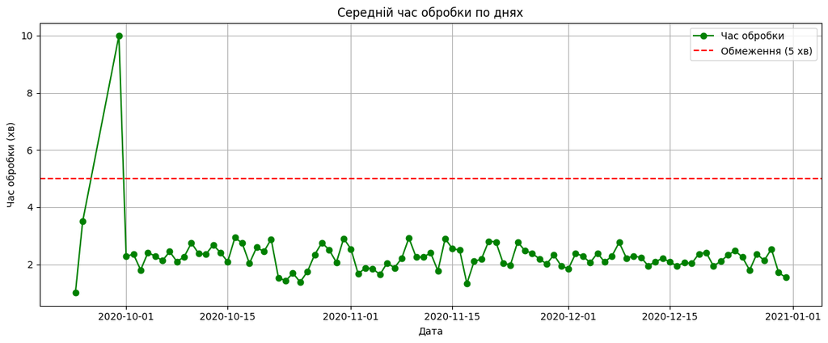

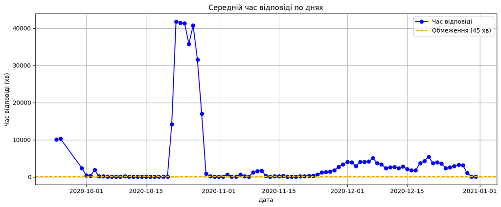

```python
# Створення колонки з датою
events_df["request_date"] = events_df["request_time"].dt.date

# Групування по днях: обчислення середнього часу обробки та відповіді
daily_stats = events_df.groupby("request_date")[["response_time", "handling_time"]].mean().reset_index()


plt.figure(figsize=(12, 5))
plt.plot(daily_stats["request_date"], daily_stats["handling_time"], marker="o", color='green', label="Час обробки")
plt.axhline(5, linestyle='--', color='red', label='Обмеження (5 хв)')

plt.title("Середній час обробки по днях")
plt.xlabel("Дата")
plt.ylabel("Час обробки (хв)")
#plt.xticks(rotation=45)
plt.grid(True)
plt.legend()
plt.tight_layout()
plt.show()

plt.figure(figsize=(12, 5))
plt.plot(daily_stats["request_date"], daily_stats["response_time"], marker="o", color='blue', label="Час відповіді")
plt.axhline(45, linestyle='--', color='orange', label='Обмеження (45 хв)')

plt.title("Середній час відповіді по днях")
plt.xlabel("Дата")
plt.ylabel("Час відповіді (хв)")
plt.grid(True)
plt.legend()
plt.tight_layout()
plt.show()
```

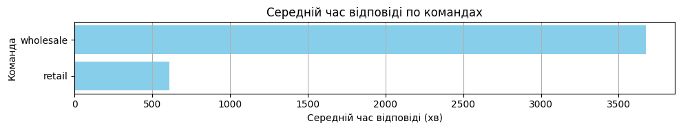

```python
team_summary = events_df.groupby("team").agg(
    total_requests=("id_request", "count"),
    avg_response_time=("response_time", "mean")
).reset_index()

team_summary = team_summary.sort_values("avg_response_time", ascending=True)

plt.figure(figsize=(10, 2))
plt.barh(team_summary["team"], team_summary["avg_response_time"], color='skyblue')
plt.title("Середній час відповіді по командах")
plt.xlabel("Середній час відповіді (хв)")
plt.ylabel("Команда")
plt.grid(axis='x')
plt.tight_layout()
plt.show()
```

### Середній час відповіді по командах

Команда **wholesale** демонструє значно вищий середній час відповіді — понад 3600 хвилин (≈2.5 доби),  
що вказує на серйозне накопичення задач або затримки з їх стартом.

Команда **retail** працює стабільніше — середній час відповіді складає близько 600 хвилин (≈10 годин),  
але також суттєво перевищує очікуваний ліміт у 45 хвилин.

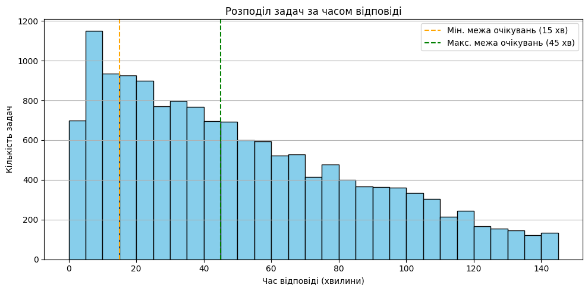

```python
plt.figure(figsize=(10, 5))
plt.hist(events_df["response_time"], bins=range(0, 150, 5), edgecolor='black', color='skyblue')

# Лінії очікувань
plt.axvline(15, color='orange', linestyle='--', label="Мін. межа очікувань (15 хв)")
plt.axvline(45, color='green', linestyle='--', label="Макс. межа очікувань (45 хв)")

# Підписи
plt.title("Розподіл задач за часом відповіді")
plt.xlabel("Час відповіді (хвилини)")
plt.ylabel("Кількість задач")
plt.grid(axis='y')
plt.legend()
plt.tight_layout()
plt.show()
```

### Розподіл задач за часом відповіді

# Аналіз FIFO: чи обробляють задачі в черговості

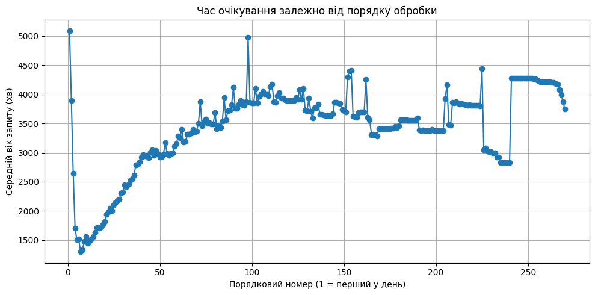

```python
# Черговість обробки в межах дня для кожного модератора
events_df["response_rank"] = events_df.sort_values("start_time").groupby(["moderator", "request_date"]).cumcount() + 1

# Середній час відповіді по кожній позиції в черзі
fifo_check = events_df.groupby("response_rank")[["response_time"]].mean().reset_index()
plt.figure(figsize=(10, 5))
plt.plot(fifo_check["response_rank"], fifo_check["response_time"], marker='o')
plt.title("Час очікування залежно від порядку обробки")
plt.xlabel("Порядковий номер (1 = перший у день)")
plt.ylabel("Середній вік запиту (хв)")
plt.grid(True)
plt.tight_layout()
plt.show()
```